# Examining Factors for NFL Draftees Value, Success, and High Draft Spots at Quarterback and Offensive or Defensive Line: 1985 to 2021

Final Project  
Data Science 1 with R (STAT 301-1)

Author

Ignacio Dowling

Published

December 7, 2023

**Github Repo Link**

https://github.com/stat301-1-2023-fall/final-project-1-idowling11

## Introduction

By cleaning, merging, and exploring different datasets covering NFL Draft Data – on prospects’ physical information, statistical information, and career accolades and outcomes – I looked to explore whether some of those metrics and factors influenced their career successes and long-term draft value for different teams. Additionally, I examined whether certain elite physical and statistical metrics in different categories played a role in helping quarterbacks and linemen earn high draft selections.

I chose to explore this data because I’m particularly interested in pro sports, but haven’t conducted a comprehensive analysis to develop my own takeaways backed by data I explored. Thus, I chose to explore data regarding 30+ years of the NFL Draft, which is one of the hardest sports institutions for a fan or expert to identify a talented player… especially as the later rounds go on.

## Data Overview and Quality

**Important**

An in-depth look at how I joined datasets and .csvs together – as well as the difference in lengths for overlapping timelines for a few of these that affected how I explored the data – can be found in the appendix.

A total of four datasets are used here. Two are joined/merged, and two are raw. One of those raw ones contains four .csv files I used. Info regarding the topics of each are in the README file. All of them arise from two data sources from Kaggle, each of which can be found in the References section. Of the raw .csvs, only nfl_draft.csv comes from the dataset created by Pedersen[^1], while the other raw ones arise from Lichtenstein’s ESPN Prospect Data.[^2]

nfl_draft.csv has 34 variables. 25 of those are numerical, with the other nine being categorical. It has 8,435 observations, and has missingness for many performance statistics as well as some attributes (such as age drafted). That is somewhat expected, since football players of different positions typically do not record statistics in every category.

nfl_draft_prospects.csv, which contains data for the players as draft prospects, has 13,354 observations and 24 variables (14 of which are categorical). The second contains textual information regarding prospects (much of which is contained in the first dataset) – it has 12,905 observations and 21 variables (13 of which are categorical).

college statistics.csv has 66,672 observations with 13 variables; four are numerical and the other 9 are categorical. Finally, college_qbr.csv has 2,049 observations, and 14 variables (12 of those 14 are numerical). None appear to have missingness.

As for the joined datasets: nfl_draft_prospect_data_and_outcomes_1985_to_2015.csv has 46 variables, and 8,435 observations. Of those 46 variables, 30 are numerical, and 16 are categorical. It has missigness for statistical information at different positions (for the same reason as the nfl_draft.csv), as well as physical attributes and ESPN ranking data, which didn’t exist for players drafted before 2004. There also was initial missigness in “team”, which I used as the secondary identifier for a player’s team name, but I resolved this by using the team abbreviation (which didn’t have missingness) as the primary team identifier.

nfl_draft_prospects_and_profiles_combined_1985_to_2021 has 9,940 observations and 23 variables, 11 of which are numerical. There’s significant missingness in the ESPN metrics and physical attributes for the same reasons mentioned above.

## Explorations

### What are Driving Factors Behind Career Success, and What Does Draft Spot Have To Do With That?

#### What drives career success?

Let’s see how a player’s career approximate value, or AV, relates to accolades that only the league’s most elite football players each season secure: Pro Bowl selections and First Team All-Pro selections. I’m defining a great career as one in which a player displays both longevity while sustaining a great performance level. Thus, in my opinion, the more All-Pro and Pro Bowl teams one makes, the better their career is.

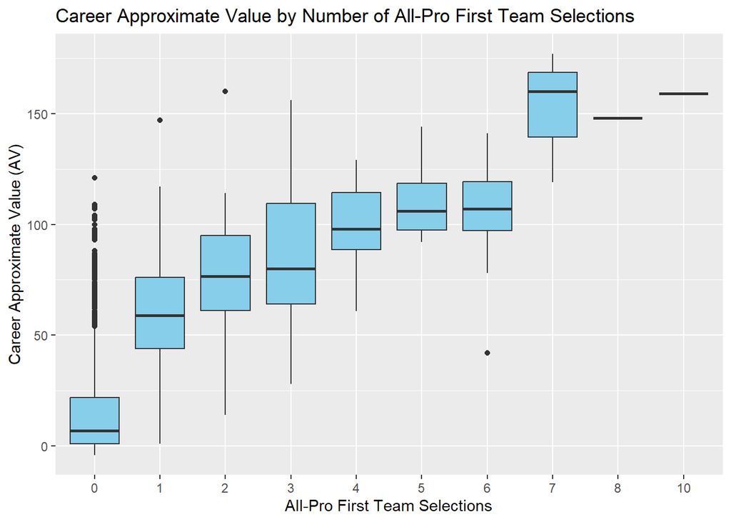

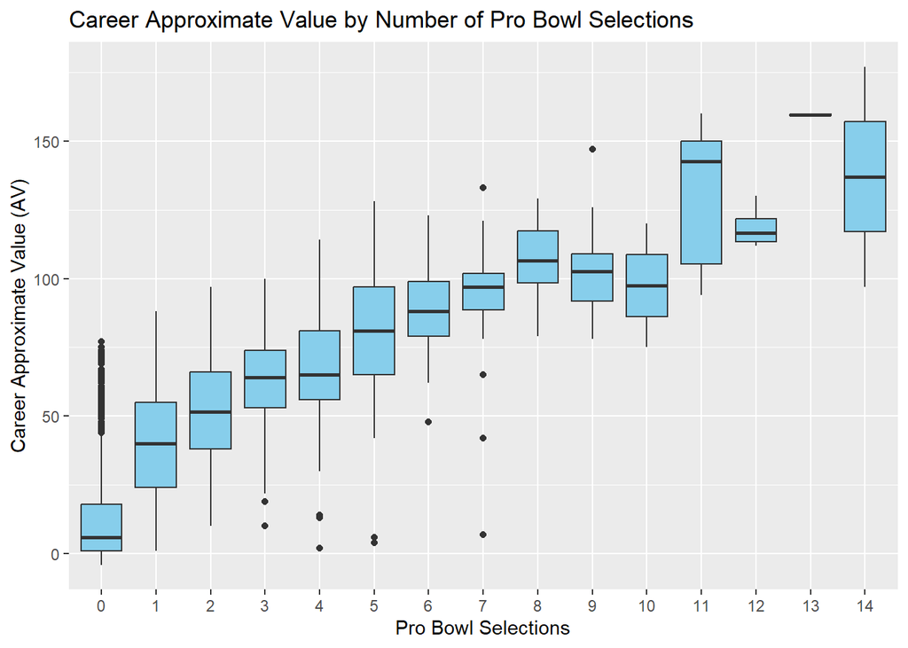

For every accolade earned, the median AV for players with a particular number of All-Pro and Pro Bowl selections tends to increase.

Univariate-wise, let’s explore the distribution of different players’ approximate values during their careers. Doing every draftee from 1985 to 2015 (that is, including young, active ones) could skew the data lower, so let’s look at the distribution for both retired players.

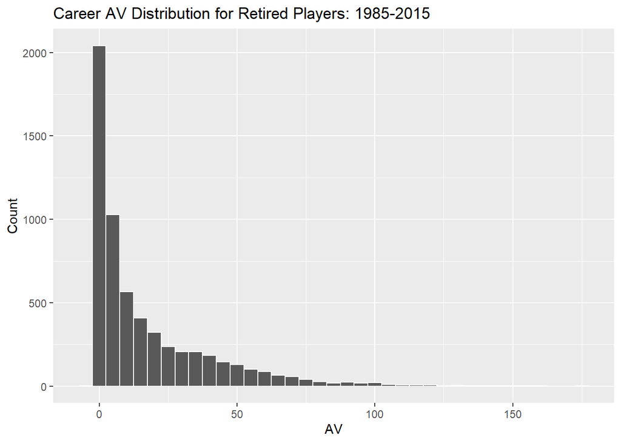

It’s apparent that career approximate value is a good measure of NFL career success: it rewards longevity and performance. It’s also clear that most drafted players don’t accumulate lots of AV. The right skew is dramatic, even without considering current players still accumulating AV as of 2015. This is potentially because of the vast number of late-round picks and the much-smaller number of starting/star roles on NFL teams. Thus, let’s explore how this varies by round; that is, if first, second, and third-rounders buck that distribution:

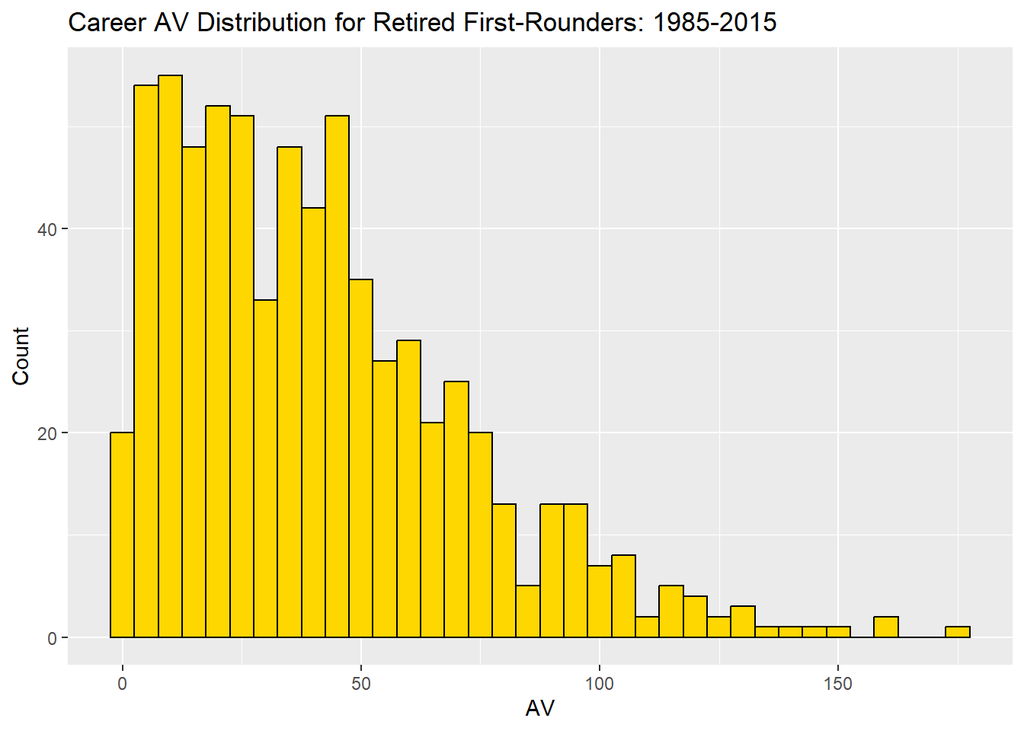

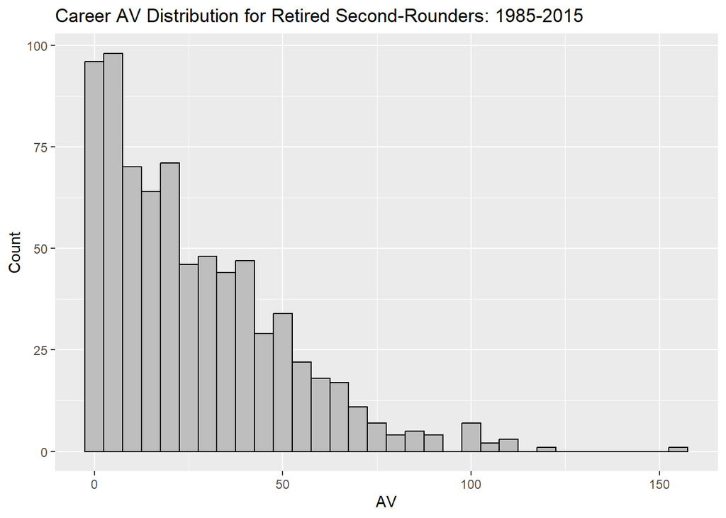

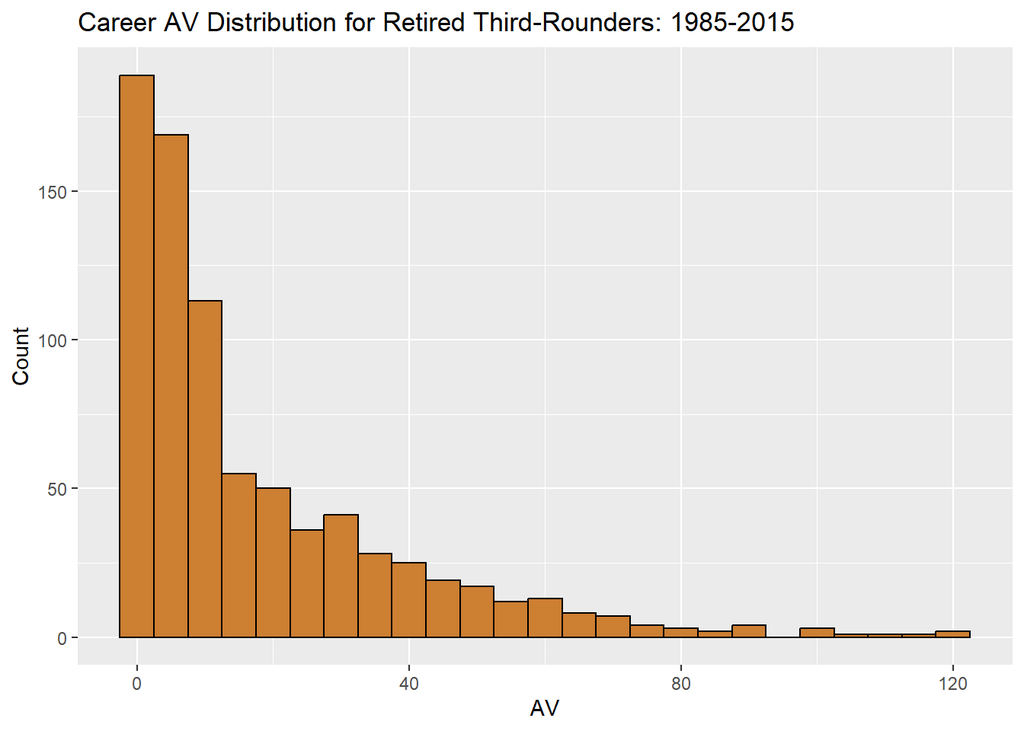

Median Approximate Value by Round for Retired Players: 1985 to 2015

| Round | Median AV |
| --- | --- |
| 1 | 36 |
| 2 | 21 |
| 3 | 9 |
| 4 | 7 |
| 5 | 4 |
| 6 | 3 |
| 7 | 2 |
| 8 | 5 |
| 9 | 2 |
| 10 | 2 |
| 11 | 1 |
| 12 | 1 |

#### Does this change drastically by pick number? Let’s look at the first two rounds.

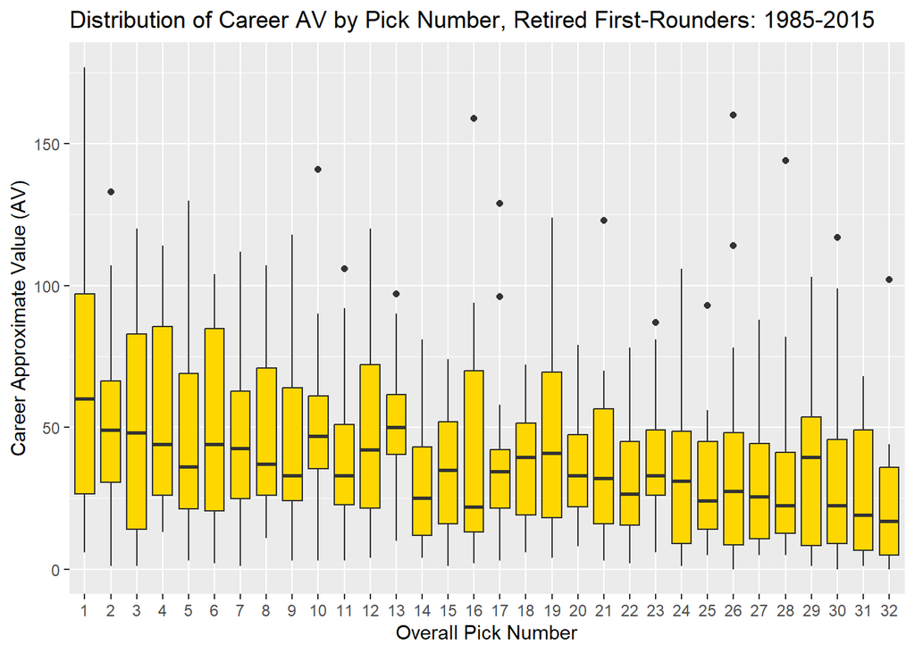

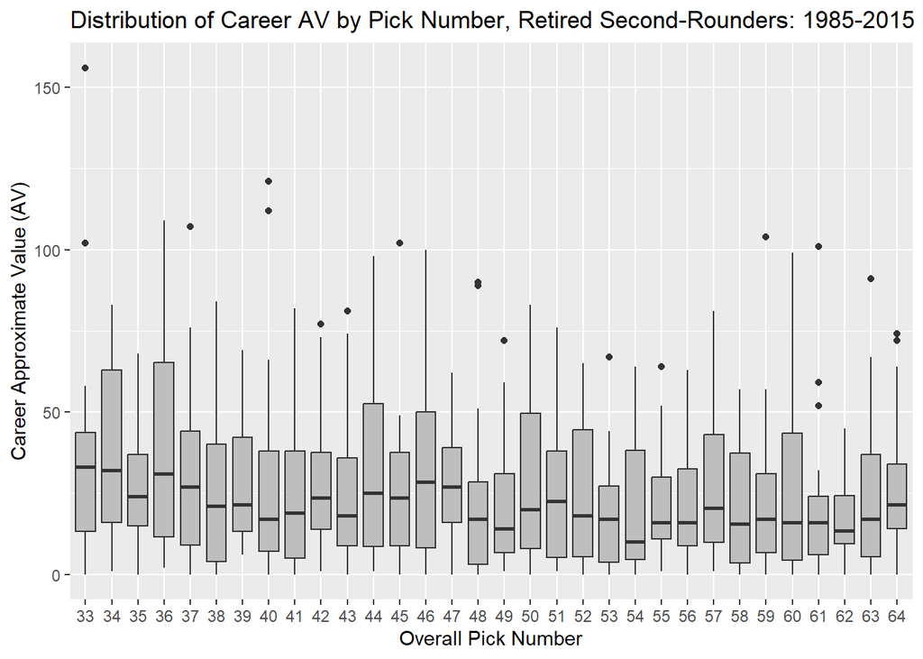

There seems to be, for the most part, a general decrease in median career AV by draft pick for the retired first-round picks. However, in the second round, there isn’t an apparent decline in the median; the 64th overall pick has a range quite similar to that of the 35th pick. You could even say that the decline in median AV slows as early as, say, the 20th pick.

So, it’s evident that there’s high value early for teams picking in the first round, and it tends to drop as the first round goes on. With first-round value looking high, that’s a nice segue…

### With First-Round Value Looking High, what Factors Potentially Indicate Getting Picked Highly in the 21st century for Different Positions?

Since the roles of different positions in football vary drastically, let’s look at this at a few positions. Given quarterbacks play the most influential position in the sport, and the steadily-declining potential value of an draft pick as the selection gets further away from No. 1, it’s imperative to identify the most elite quarterback prospects. It begs the question:

#### Are the top QBs in college the highest-picked in the NFL Draft?

To get a sense of this, let’s look at who the best quarterbacks were in college, statistically, since 2004. Let’s start examining collegiate seasons with estimated points added (EPA), which is widely regarded[^3] as the best statistic to capture overall offensive impact, and then examine top seasons by quarterback ratings (QBR):

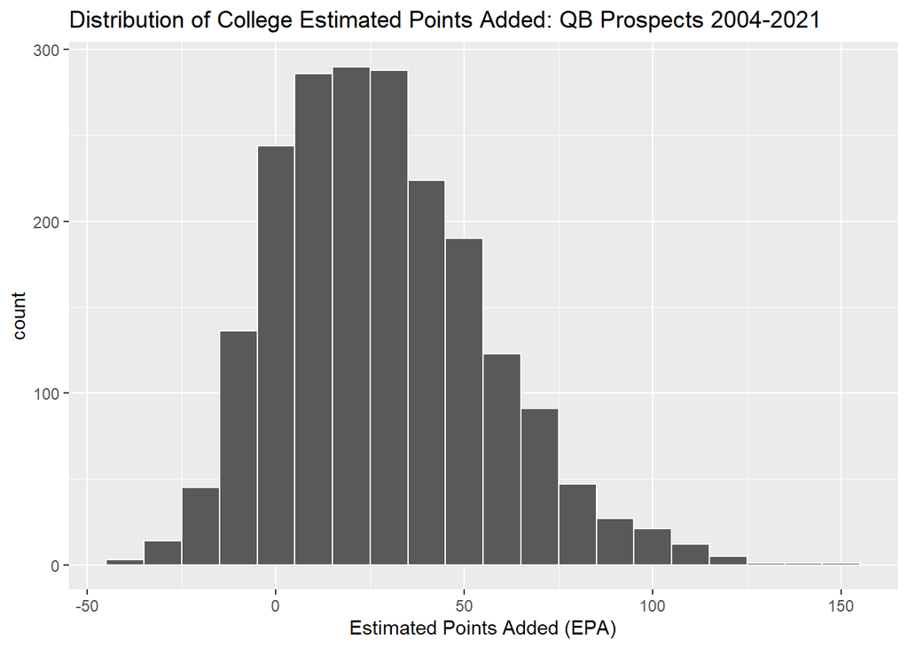

Top 25 College Quarterback Seasons by Estimated Points Added Since 2004

| Name | NCAA Season | EPA |
| --- | --- | --- |
| Joe Burrow | 2019 | 147.9 |
| Kyler Murray | 2018 | 143.1 |
| Colt Brennan | 2006 | 127.5 |
| Marcus Mariota | 2014 | 122.4 |
| Johnny Manziel | 2012 | 121.8 |
| Case Keenum | 2009 | 117.2 |
| Mac Jones | 2020 | 116.5 |
| Patrick Mahomes | 2016 | 116.0 |
| Baker Mayfield | 2017 | 114.7 |
| McKenzie Milton | 2017 | 113.2 |
| Colin Kaepernick | 2010 | 110.3 |
| Jalen Hurts | 2019 | 109.6 |
| Chase Clement | 2008 | 108.0 |
| Quinton Flowers | 2016 | 108.0 |
| Cody Fajardo | 2012 | 107.7 |
| Cam Newton | 2010 | 107.6 |
| Derek Carr | 2013 | 107.6 |
| Deshaun Watson | 2015 | 107.3 |
| Anthony Gordon | 2019 | 107.1 |
| Mason Rudolph | 2017 | 105.4 |
| Taylor Heinicke | 2013 | 103.6 |
| Colt McCoy | 2008 | 103.5 |
| Sam Bradford | 2008 | 102.7 |
| Brandon Doughty | 2014 | 102.3 |
| Graham Harrell | 2007 | 102.2 |

This is a fairly normal distribution, and it appears that QBs with seasons where they accumulated an EPA over 100 fall near the top end of the range. Let’s see how many of these names are near the top of the QBR list:

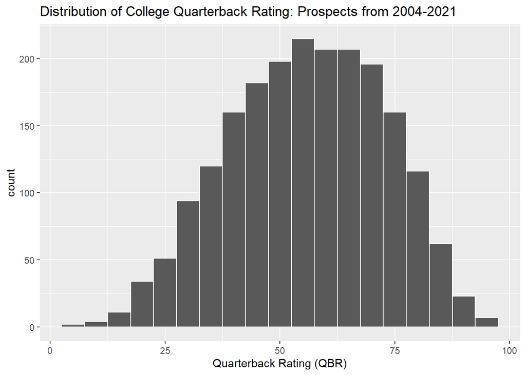

Top 25 College Quarterback Ratings Since 2004

| Name | NCAA Season | QBR |
| --- | --- | --- |
| Mac Jones | 2020 | 96.1 |
| Kyler Murray | 2018 | 95.4 |
| Joe Burrow | 2019 | 94.9 |
| Tua Tagovailoa | 2019 | 94.8 |
| Russell Wilson | 2011 | 94.1 |
| Andrew Luck | 2010 | 93.8 |
| Tua Tagovailoa | 2018 | 93.1 |
| Baker Mayfield | 2017 | 92.3 |
| Justin Fields | 2019 | 92.1 |
| Khalil Tate | 2017 | 92.0 |
| Sam Bradford | 2008 | 91.9 |
| Baker Mayfield | 2016 | 91.8 |
| Justin Fields | 2020 | 91.7 |
| Johnny Manziel | 2012 | 91.3 |
| Marcus Mariota | 2014 | 91.3 |
| Pat White | 2006 | 90.5 |
| Jameis Winston | 2013 | 90.2 |
| Cam Newton | 2010 | 90.0 |
| Seth Russell | 2015 | 89.9 |
| Matt Corral | 2020 | 89.9 |
| Jalen Hurts | 2019 | 89.7 |
| Kellen Moore | 2010 | 89.4 |
| Marcus Mariota | 2013 | 89.4 |
| Zach Wilson | 2020 | 88.6 |
| Kyle Trask | 2020 | 88.5 |

For good measure, here are the quarterbacks who fall inside the top 25s on both of these lists:

Top College Quarterbacks by EPA and QBR since 2004

| Name | NCAA Season | QBR | EPA |
| --- | --- | --- | --- |
| Joe Burrow | 2019 | 94.9 | 147.9 |
| Kyler Murray | 2018 | 95.4 | 143.1 |
| Marcus Mariota | 2014 | 91.3 | 122.4 |
| Johnny Manziel | 2012 | 91.3 | 121.8 |
| Mac Jones | 2020 | 96.1 | 116.5 |
| Baker Mayfield | 2017 | 92.3 | 114.7 |
| Jalen Hurts | 2019 | 89.7 | 109.6 |
| Cam Newton | 2010 | 90.0 | 107.6 |
| Sam Bradford | 2008 | 91.9 | 102.7 |

Obviously, it’s a short list; in fact, every single one of those players were Heisman Trophy finalists. Let’s look at how all of those top players on each of these lists fared in the draft process, though. Are these statistics good predictors for quarterbacks? One should expect all of those elite players to be early first-round draft picks…

[figure not shown]

It’s clear that in a multivariate examination, the quarterbacks that are the most elite of the elite in both statistics tend to be highly-graded, highly-drafted players. At the very least, they’re almost always first-rounders. With the exception of Jalen Hurts, a second-round quarterback, this was the case.

Let’s look at this with each individual statistic. Does this remain the case if we only consider the top quarterbacks for EACH statistic? We’ll take away the nine quarterbacks evaluated above, just to get a sense of how quarterbacks who only excelled in one area fared.

[figure not shown]

Not one of these players has an ESPN grade above 90, and a whopping eight of them went undrafted. Considering the other nine players graphed above, EPA does somewhat affect draft status for the most elite quarterbacks, but not necessarily alone. Now, for QBR:

[figure not shown]

However, it’s apparent that both high QBR and high EPA, when taken together into consideration, are a better predictor of draft status for the best college quarterbacks.

#### Do weight and height for linemen (and quarterbacks) possess a relationship with high draft status?

More so than any other position, offensive and defensive linemen rely on strength, and tend to be the players that weigh the most on the field. So, in the process of looking for factors that lead to high draft status, it’s worth exploring if weight and height contribute to that at a position where those variables appear to matter most.

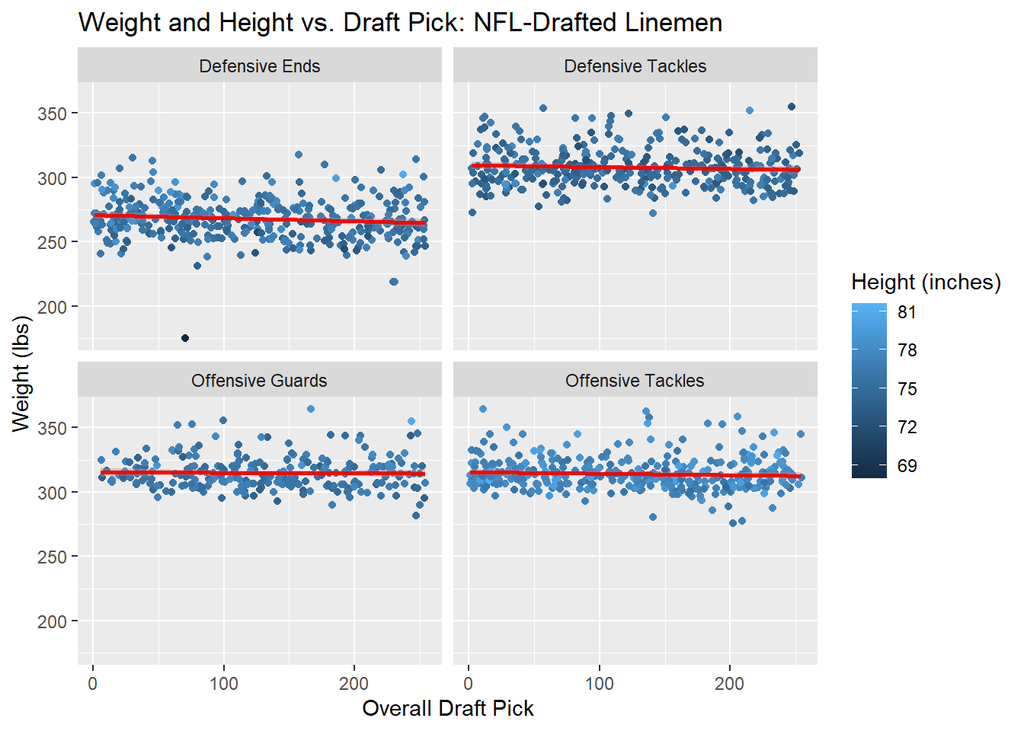

Weight and draft status appear to have almost no relationship for each of these positions. A player’s height has a marginally positive relationship with their overall draft pick, but only for defensive ends. Ultimately, neither of these factors are significant predictors. Height and weight weren’t recorded for prospects prior to 2004 – a limitation of this data – but how has this relationship changed in the recent decades?

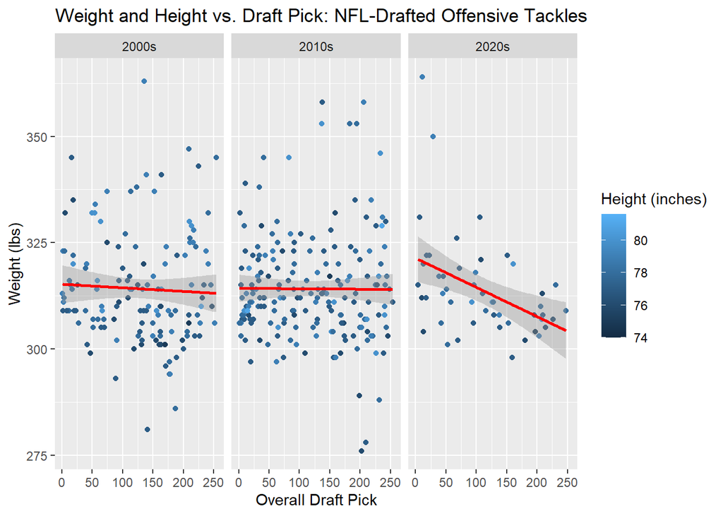

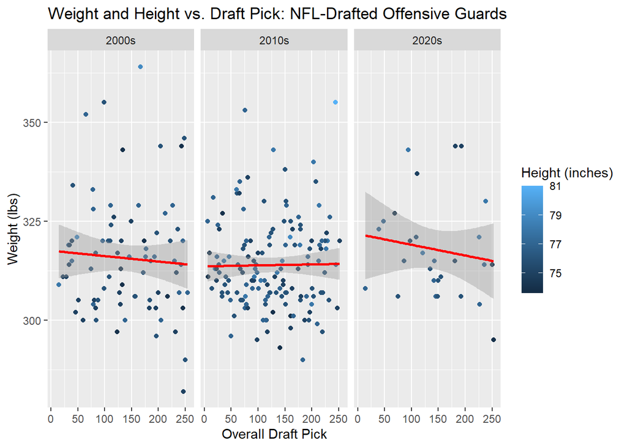

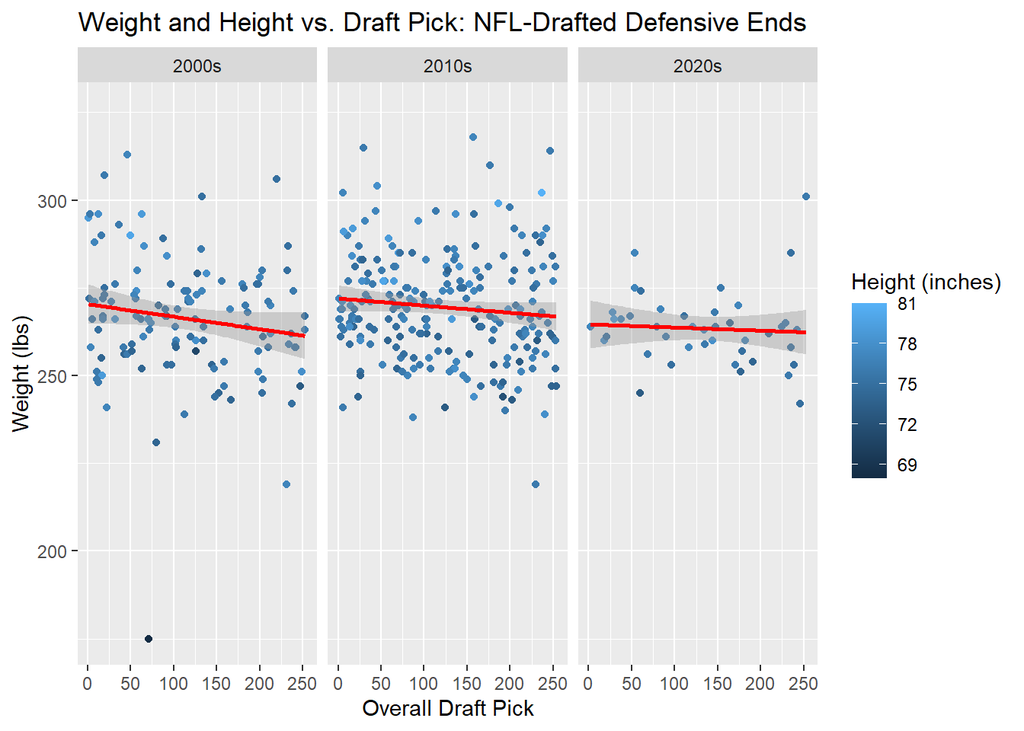

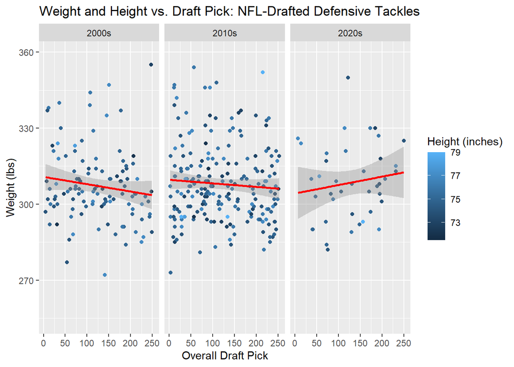

The typical weight for drafted linemen hasn’t actually varied drastically over the course of the 21st century. The only decade with 10 years of data – the 2010s – suggests that there isn’t a strong relationship between draft pick, height, and weight.

However, it appears that NFL teams are starting to tend to value heavier offensive tackles and guards. In contrast, it seems like a defensive end’s weight matters less than it did about 20 years ago in considering how early they come off the draft board. A similar trend exists for defensive tackles. At that position, especially, height looks like it is starting to become a slightly greater factor in the 2020s drafts. Granted, the data only examines two drafts in the 2020s, which is worth noting. Nevertheless, the progression over these three decades indicates those small changes.

Let’s examine height for quarterbacks. It’s a metric that, at that particular position, has sparked lots of debate around prospects who aren’t tall but possess other great skills[^4]. Firstly, let’s look at the height distribution for drafted QBs since 2004.

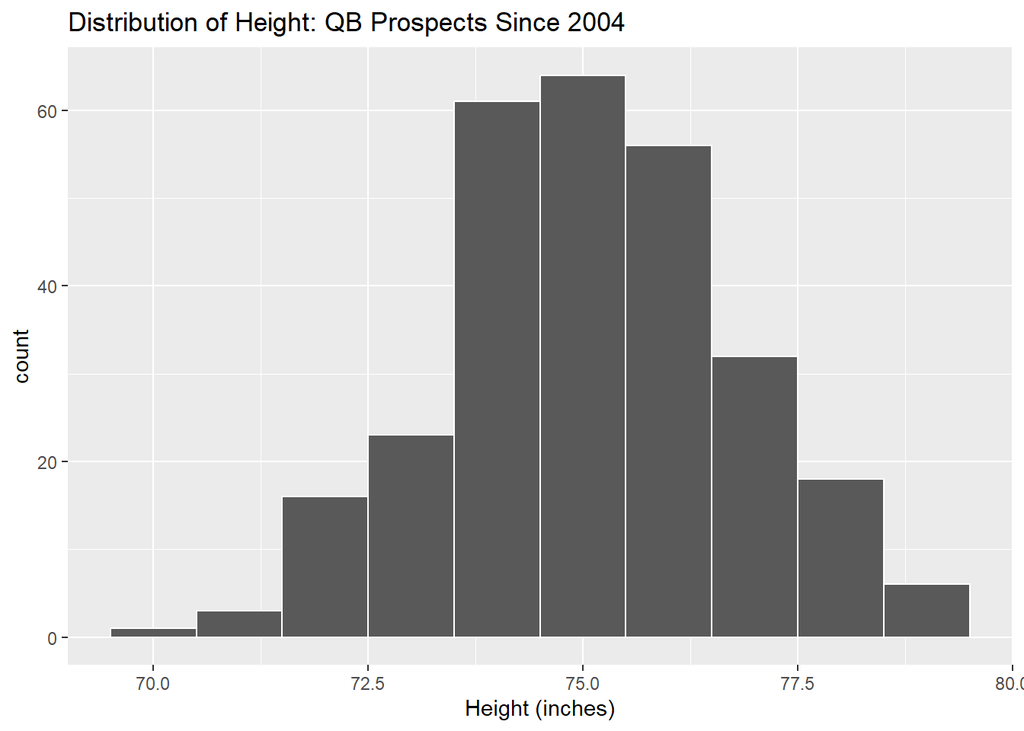

Most quarterbacks appear to be between 6 feet even and 6’5”. With that in mind, is there a trend between height and draft spot? And, does it put the outliers (both very tall and very short) in danger?

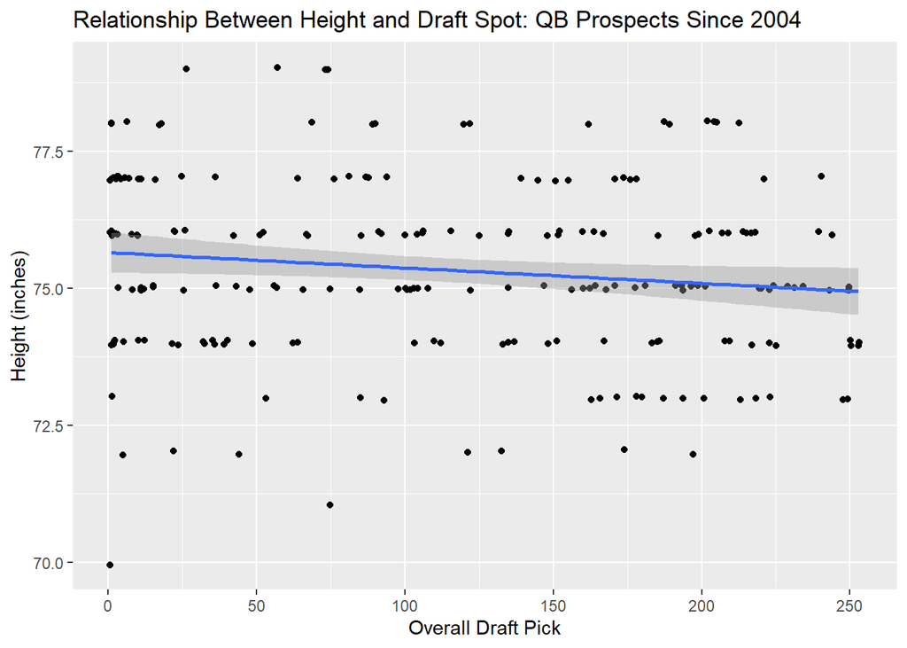

There is a slight – but not significant – positive relationship between a quarterback’s height and their draft position. Now, as we examined for linemen, has this changed over the past 20 years or so? Firstly, let’s look at the distribution of quarterback prospect heights by year.

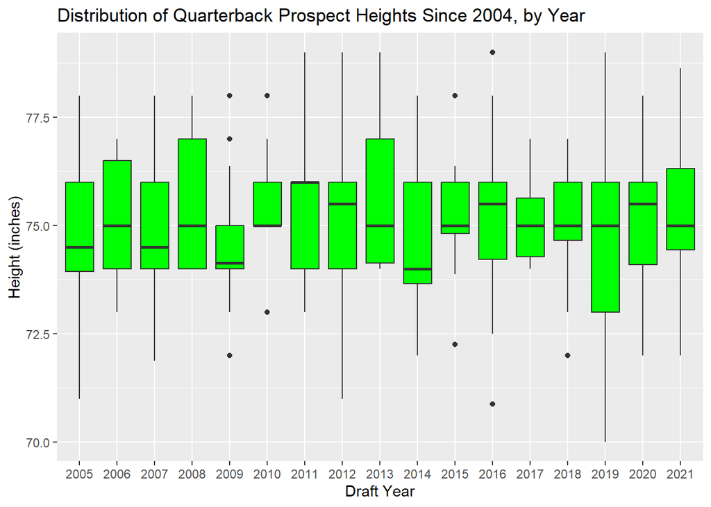

While the median quarterback prospect height has bounced around since 2004, it has hovered around 6’3”, for the most part. How has this varied in relationship to draft status over time?

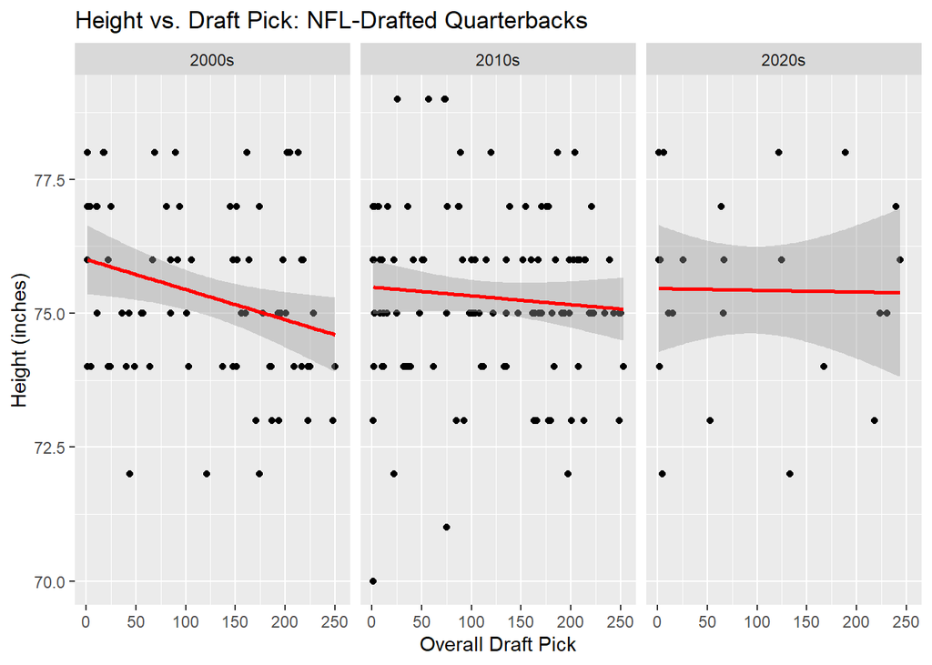

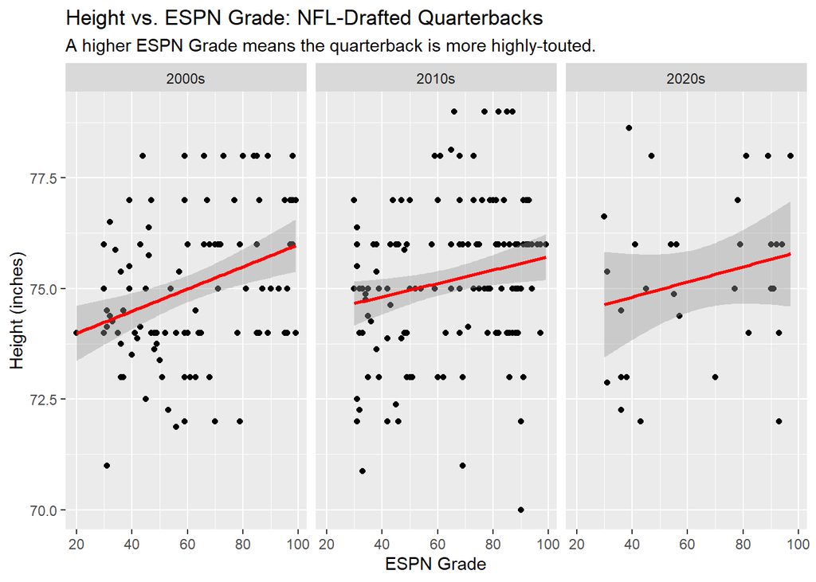

In the 2000s, the relationship between a quarterback’s height and where they were drafted appeared to be moderately strong – the average height of a quarterback by draft spot tended to decrease as the draft went on. However, in the 2010s and 2020s, that hasn’t necessarily been the case. In fact, in the last two drafts in the 2020s, the trendline is almost constant.

Ironically, when it comes to the scouting experts (those at ESPN), the highest-ranked quarterbacks tends to be taller than the lowest-ranked ones – and that hasn’t changed since the 2000s.

However, in all of these cases, there are both a significant number of shorter and taller outliers that are both highly-ranked and lowly-ranked. Thus, although height matters when it comes to draft prestige to an extent, it’s not the end-all, be-all for a quarterback’s draft position.

Now, looking at different players’ long-term values:

### What Makes a Successful Draft Pick, Long-Term? And Who are the Most Successful Ones?

We’ve already explored the median AV by round, and its distribution for each of the first 64 picks for retired players. A top-5 draft pick may have a high AV relative to a third-rounder, but that doesn’t make them a high-value pick (or a good one), even if they’re the more valuable player!

So, let’s bring a new metric into the fold: approximate value over expected (AVOE). I’ll define it as a player’s approximate value subtracted by the median AV for retired players near their draft spot.

Granted, as we saw in some of the earlier explorations, the median AV for a player doesn’t steadily decrease with every pick after the first round. Plus, different teams at different spots may pass on a slightly better player to fill a positional need, especially later in the draft. Thus, I’ll designate the “median AV” compared to each player as the median AV of a five-spot cluster. For instance, a No. 1 overall pick’s AV over expected in this EDA would be their approximate value minus the median AV of retired picks No. 1 through No. 5 since 1985. A No. 6 pick would be compared to the median AVs for overall picks 6-10, a No. 11 pick for a median among picks 11-15, etc.

Here are the 25 players who either retired before 2016 or are active players at least five players removed from being drafted who have surpassed expectations relative to their draft spot the most:

#### Top 25 Retired Players with Highest Approximate Value Over Expected

Top 25 Players with Highest Approximate Value Over Expected Since 1985

| Name | Position | Round | Overall Pick | Draft Year | Total AV | Median 5-Pick Cluster AV | AV Over Expected |
| --- | --- | --- | --- | --- | --- | --- | --- |
| Tom Brady | QB | 6 | 199 | 2000 | 160 | 1.0 | 159.0 |
| Ray Lewis | LB | 1 | 26 | 1996 | 160 | 27.0 | 133.0 |
| Brett Favre | QB | 2 | 33 | 1991 | 156 | 25.5 | 130.5 |
| Peyton Manning | QB | 1 | 1 | 1998 | 177 | 53.0 | 124.0 |
| Jerry Rice | WR | 1 | 16 | 1985 | 159 | 36.0 | 123.0 |
| Drew Brees | QB | 2 | 32 | 2001 | 147 | 25.5 | 121.5 |
| Derrick Brooks | LB | 1 | 28 | 1995 | 144 | 27.0 | 117.0 |
| Zach Thomas | LB | 5 | 154 | 1996 | 118 | 3.0 | 115.0 |
| Terrell Owens | WR | 3 | 89 | 1996 | 119 | 7.0 | 112.0 |
| Jason Taylor | DE | 3 | 73 | 1997 | 119 | 10.0 | 109.0 |
| Will Shields | G | 3 | 74 | 1993 | 114 | 10.0 | 104.0 |
| Ronde Barber | DB | 3 | 66 | 1997 | 111 | 10.0 | 101.0 |
| Tom Nalen | C | 7 | 218 | 1994 | 101 | 1.0 | 100.0 |
| Rod Woodson | DB | 1 | 10 | 1987 | 141 | 42.0 | 99.0 |
| Michael Strahan | DE | 2 | 40 | 1993 | 121 | 23.0 | 98.0 |
| Jahri Evans | T | 4 | 108 | 2006 | 103 | 7.5 | 95.5 |
| Jared Allen | DE | 4 | 126 | 2004 | 99 | 4.0 | 95.0 |
| Hardy Nickerson | LB | 5 | 122 | 1987 | 99 | 4.0 | 95.0 |
| Bruce Smith | DE | 1 | 1 | 1985 | 148 | 53.0 | 95.0 |
| Trent Green | QB | 8 | 222 | 1993 | 94 | 1.0 | 93.0 |
| Emmitt Smith | RB | 1 | 17 | 1990 | 129 | 36.0 | 93.0 |
| Mark Brunell | QB | 5 | 118 | 1993 | 96 | 4.0 | 92.0 |
| Steve Smith | WR | 3 | 74 | 2001 | 101 | 10.0 | 91.0 |
| Curtis Martin | RB | 3 | 74 | 1995 | 101 | 10.0 | 91.0 |
| Greg Lloyd | LB | 6 | 150 | 1987 | 93 | 2.0 | 91.0 |

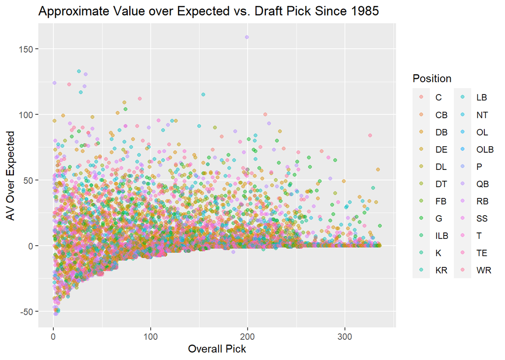

This gives a sense that first-rounders are the ones who tend to dominate (and, by extension, more likely to fail badly with a higher median AV). It also looks like the surprise breakouts separate themselves at about the 50-AVOE mark. Going further, let’s look at the pick distribution for players with an AV over expected that’s either 50 or above:

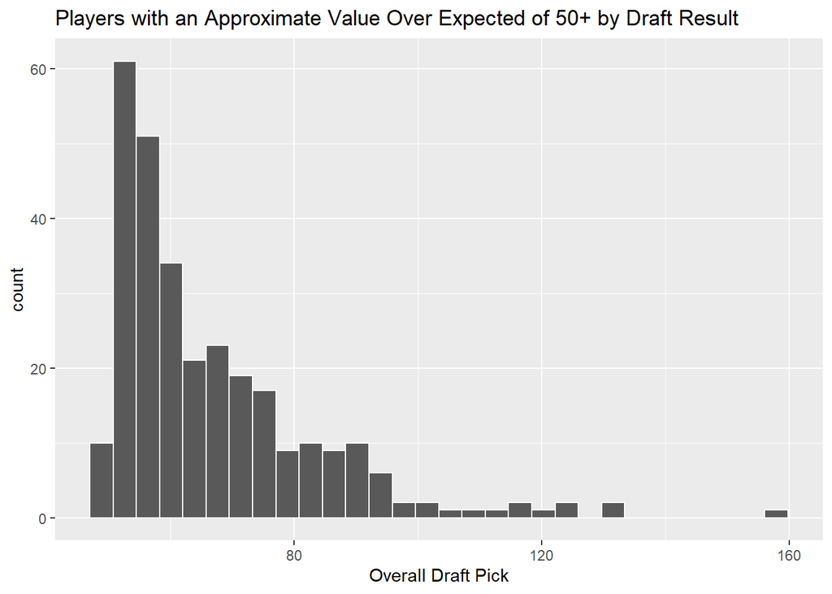

#### Diamonds in the Rough

That’s what makes finding an unsung talent that blossoms so impressive. It’s worth examining. Using the median table by round as a framework far above, let’s define “unsung” as a prospect who falls outside of the top 64. The top 25 players in AV over Expected for players drafted after the 64th pick are as follows:

Top 25 Retired Players with Highest AV Over Expected Since 1985, Drafted Round 3 or Later

| Name | Position | Round | Overall Pick | Draft Year | Total AV | Median 5-Pick Cluster AV | AV Over Expected |
| --- | --- | --- | --- | --- | --- | --- | --- |
| Tom Brady | QB | 6 | 199 | 2000 | 160 | 1.0 | 159.0 |
| Zach Thomas | LB | 5 | 154 | 1996 | 118 | 3.0 | 115.0 |
| Terrell Owens | WR | 3 | 89 | 1996 | 119 | 7.0 | 112.0 |
| Jason Taylor | DE | 3 | 73 | 1997 | 119 | 10.0 | 109.0 |
| Will Shields | G | 3 | 74 | 1993 | 114 | 10.0 | 104.0 |
| Ronde Barber | DB | 3 | 66 | 1997 | 111 | 10.0 | 101.0 |
| Tom Nalen | C | 7 | 218 | 1994 | 101 | 1.0 | 100.0 |
| Jahri Evans | T | 4 | 108 | 2006 | 103 | 7.5 | 95.5 |
| Jared Allen | DE | 4 | 126 | 2004 | 99 | 4.0 | 95.0 |
| Hardy Nickerson | LB | 5 | 122 | 1987 | 99 | 4.0 | 95.0 |
| Trent Green | QB | 8 | 222 | 1993 | 94 | 1.0 | 93.0 |
| Mark Brunell | QB | 5 | 118 | 1993 | 96 | 4.0 | 92.0 |
| Steve Smith | WR | 3 | 74 | 2001 | 101 | 10.0 | 91.0 |
| Curtis Martin | RB | 3 | 74 | 1995 | 101 | 10.0 | 91.0 |
| Greg Lloyd | LB | 6 | 150 | 1987 | 93 | 2.0 | 91.0 |
| Andre Reed | WR | 4 | 86 | 1985 | 98 | 7.0 | 91.0 |
| La’Roi Glover | DT | 5 | 166 | 1996 | 91 | 1.0 | 90.0 |
| Rich Gannon | QB | 4 | 98 | 1987 | 99 | 9.0 | 90.0 |
| Lance Briggs | LB | 3 | 68 | 2003 | 98 | 10.0 | 88.0 |
| Kevin Greene | LB | 5 | 113 | 1985 | 95 | 7.0 | 88.0 |
| Matt Hasselbeck | QB | 6 | 187 | 1998 | 88 | 1.0 | 87.0 |
| Clyde Simmons | DE | 9 | 233 | 1986 | 87 | 0.0 | 87.0 |
| Keenan McCardell | WR | 12 | 326 | 1991 | 84 | 0.0 | 84.0 |
| Seth Joyner | LB | 8 | 208 | 1986 | 85 | 1.0 | 84.0 |
| Matt Birk | C | 6 | 173 | 1998 | 84 | 1.0 | 83.0 |

These high outliers are also diverse in position and in round, though it’s worth wondering if this varies greatly by position when taking all of the late-round, big success stories into account. Using that 50-AVOE marker as the threshold, here’s the position breakdown for players who meet that requirement and were drafted after Pick 64:

Players with 50+ AV over Expected Drafted Round 3 or Later: Position Breakdown

| Position | Number of Players with 50+ AV over Expected |
| --- | --- |
| LB | 30 |
| DE | 22 |
| G | 22 |
| WR | 22 |
| T | 19 |
| DB | 18 |
| QB | 17 |
| DT | 12 |
| RB | 12 |
| C | 8 |
| TE | 2 |
| NT | 1 |

Have certain teams done a better job at identifying those players than others?

#### Which Teams Have Had the Best Eyes for Long-Term Value?

To build off finding late-round value, since we’ve established that that’s toughest, let’s start there.

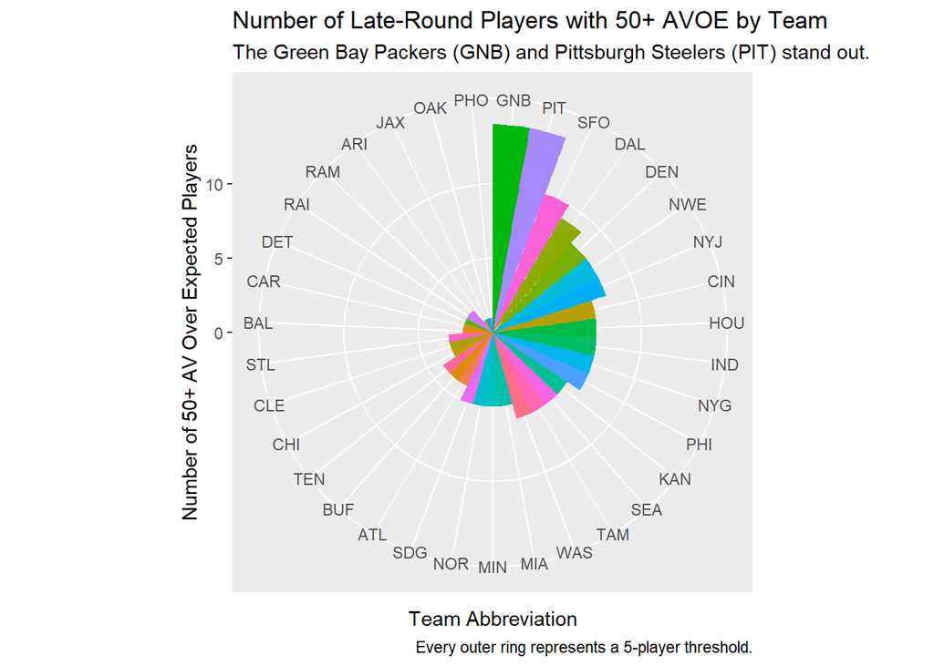

The Green Bay Packers and Pittsburgh Steelers especially stand out, drafting almost 15 of these “diamonds in the rough” apiece. The difference between those teams and the rest of the league demonstrate over a stretch spanning multiple decades demonstrates that they are uniquely talented at identifying these diamonds in the rough.

To wrap up this EDA, though, let’s tie this in together with value across the draft – including in early rounds. While identifying the diamonds in the rough is most impressive, snagging players with higher values than expected at any spot is impactful. So, which teams have been historically most (and least) successful at drafting long-term value overall?

#### How Have Teams’ Cumulative AV Over Expected Changed over Time?

To get a better visual picture, let’s evaluate this by conference: AFC and NFC teams (16 teams in each, splitting the 32-team league evenly).

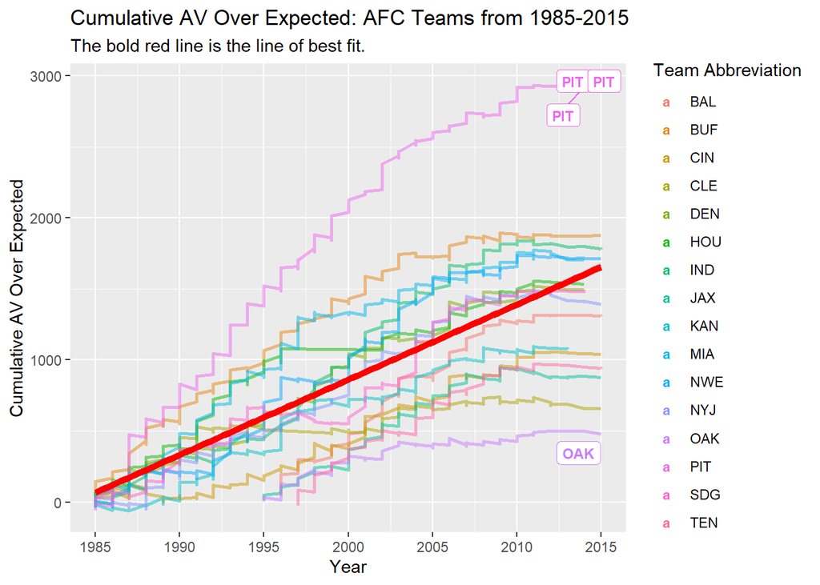

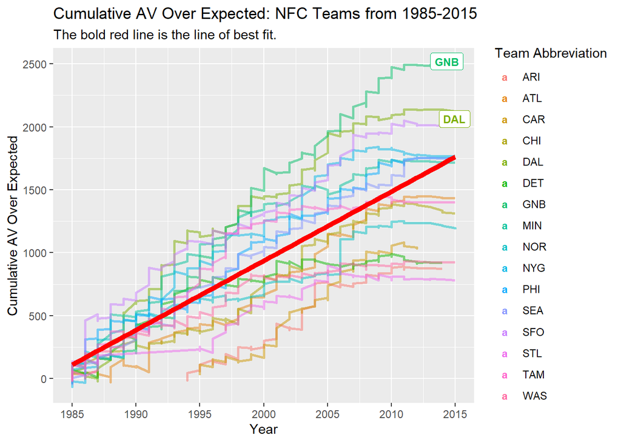

There are a number of takeaways from this. As they did in finding talent in the later rounds, the Pittsburgh Steelers and Green Bay Packers excel here. The Steelers, in particular, have a much higher cumulative approximate value over expected than the other teams. The team with the lowest cumulative total is the (formerly) Oakland Raiders.

Additionally, it’s clear that over time, cumulative AV over expected for teams tends to increase. This makes sense, as the majority of draft picks are remarkably close to the lower limit for a player’s approximate value (0), meaning that there’s not much room for disappointment for, say, a late-round pick in a cluster with a median AV of 1. However, there’s a lot of room to exceed expectations. The biggest “bust,” Cincinnati Bengals quarterback and 1999 No. 1 overall pick Akili Smith, has the lowest AV over expected since 1985 at -52. Meanwhile, as we explored, a late-round pick with a +52 AV over expected only slightly stands out from the crowd. Thus, overall growth – despite some down years – is almost a certainty over three decades for most teams.

## Conclusion

Ultimately, these three explorations help us equate success with approximate value, “value” with AV relative to similar draftees, and “high draft status” for quarterbacks and linemen as a product of a number of factors, namely EPA and QBR for the elite of the elite quarterbacks. It’s worth noting that the overlap of this data may have been a limiting factor; having more physical and college statistical data to work with – especially for quarterbacks – could have been helpful in solidifying interpretations and analyses of certain trends.

## References

Bell, J. (2023, March 4). Bryce Young might ultimately prove to NFL his small build isn’t a problem | opinion. USA Today. https://www.usatoday.com/story/sports/nfl/columnist/bell/2023/03/03/bryce-young-weight-height-nfl-quarterback-draft-combine/11394682002/.

Football nose tackle. rookieroad.com. (n.d.). https://www.rookieroad.com/football/positions/nose-tackle/.

Jurgens, T. (2022, November 1). Betting 101: Explaining commonly cited metrics and factors in our handicapping: NFL and NCAA betting picks. PFF. https://www.pff.com/news/bet-nfl-bet-terms-metrics-game-script-handicapping-success-rate-epa#:~:text=Expected%20Points%20Added%20(EPA),-Expected%20Points%20Added&text=For%20every%20play%2C%20EPA%20is,disparity%20in%20total%20plays%20run.

Lichtenstein, J. (2021, May 5). ESPN NFL draft prospect data. Kaggle. https://www.kaggle.com/datasets/jacklichtenstein/espn-nfl-draft-prospect-data/data.

Pedersen, U. T. (2023, March 2). NFL draft 1985-2015. Kaggle. https://www.kaggle.com/datasets/ulrikthygepedersen/nfl-draft-1985-2015.

## Appendix: Technical Info

### Foundation for Cleaning: Raw Dataset Timelines

| Outcomes Start Year | Outcomes End Year | QB Data Start Year | QB Data End Year | College Stats Start Year | College Stats End Year | Prospect Data Start Year | Prospect Data End Year |
| --- | --- | --- | --- | --- | --- | --- | --- |
| 1985 | 2015 | 2004 | 2020 | 2014 | 2020 | 1967 | 2021 |

To get a sense of which years we should work with in answering some of the research questions, and in joining some of the datasets to clean them and answer questions, I found the timelines for the sets which contain years for each player observation. While the reader won’t see me work with this data, I think that it’s necessary context for interpreting the analysis that I’ll conduct.

In working with quarterback data for prospects in their last years of college football and comparing them to league success, we should use quarterbacks from 2004 to 2015. In comparing data from all prospects to their NFL outcomes (that is, nfl_draft_prospect_data vs. outcomes) – the two largest datasets here – I’ll aim to focus on the years 1985 to 2015.

Comparing the collegiate stats dataset to professional outcomes may not be as beneficial to developing any insights, since their intersection is just a year (2014 to 2015). However, though, in joining datasets and conducting multivariate analysis, this table gives me a sense of the time crossovers of the datasets in question.

## Footnotes

[^1]: See Reference 5.
[^2]: See Reference 4.
[^3]: See Reference 3.
[^4]: See Reference 1
[^5]: See Reference 2